# AI-Driven Revenue Recovery from Failed Digital Payment Transactions

### Full working prototype — Failure Classifier + Recommendation Engine + Impact Dashboard

**Pipeline:**

1. Simulate realistic failed-transaction data (stand-in for real gateway logs)
2. Train an AI model to classify *why* each payment failed
3. Build a recommendation engine that picks the best recovery action per failure cause + customer context
4. Simulate the full pipeline end-to-end and compare against the industry-standard static retry baseline
5. Visualize the business impact
6. Live demo: score a brand-new transaction in real time

Run all cells top to bottom.

## Step 1 — Generate Synthetic Failed-Transaction Data

```python
"""
STEP 1 — Synthetic Data Generation
==================================
Simulates a realistic stream of FAILED digital payment transactions.
Each failed transaction has a hidden "true cause" and observable signals
that a real payment gateway would log (bank response code, network
latency, fraud score, customer history, etc).

In production, this data would come from your payment gateway logs
(Stripe, Razorpay, PayU, bank webhooks, etc). Here we simulate it so
the whole pipeline is reproducible and demo-able.
"""

import numpy as np
import pandas as pd

np.random.seed(42)

N = 8000  # number of failed transactions to simulate

FAILURE_CAUSES = [
    "insufficient_funds",
    "bank_timeout",
    "network_error",
    "fraud_false_positive",
]

# Ground-truth cause distribution (realistic-ish skew)
cause_probs = [0.40, 0.22, 0.23, 0.15]

rows = []
for i in range(N):
    cause = np.random.choice(FAILURE_CAUSES, p=cause_probs)

    # --- Feature generation, correlated with the true cause ---
    if cause == "insufficient_funds":
        amount = np.random.gamma(shape=2.0, scale=1800)          # larger amounts
        bank_response_code = np.random.choice([51, 61, 65], p=[0.7, 0.2, 0.1])
        network_latency_ms = np.random.normal(180, 40)
        fraud_score = np.random.beta(2, 8)                       # low fraud score
        prior_failed_attempts_24h = np.random.poisson(1.2)
        customer_tenure_days = np.random.exponential(400)
        account_balance_signal = np.random.beta(2, 6)            # low balance signal
    elif cause == "bank_timeout":
        amount = np.random.gamma(shape=2.0, scale=1000)
        bank_response_code = np.random.choice([91, 96, 68], p=[0.5, 0.3, 0.2])
        network_latency_ms = np.random.normal(350, 80)
        fraud_score = np.random.beta(2, 8)
        prior_failed_attempts_24h = np.random.poisson(0.6)
        customer_tenure_days = np.random.exponential(500)
        account_balance_signal = np.random.beta(4, 4)
    elif cause == "network_error":
        amount = np.random.gamma(shape=2.0, scale=900)
        bank_response_code = np.random.choice([96, 21, 5], p=[0.5, 0.3, 0.2])
        network_latency_ms = np.random.normal(500, 120)          # highest latency
        fraud_score = np.random.beta(2, 8)
        prior_failed_attempts_24h = np.random.poisson(0.4)
        customer_tenure_days = np.random.exponential(500)
        account_balance_signal = np.random.beta(4, 4)
    else:  # fraud_false_positive
        amount = np.random.gamma(shape=2.0, scale=2500)          # unusually large/odd amounts
        bank_response_code = np.random.choice([59, 63, 5], p=[0.6, 0.2, 0.2])
        network_latency_ms = np.random.normal(200, 50)
        fraud_score = np.random.beta(8, 3)                       # high fraud score (but false)
        prior_failed_attempts_24h = np.random.poisson(0.3)
        customer_tenure_days = np.random.exponential(900)        # often long-standing customers
        account_balance_signal = np.random.beta(6, 3)

    payment_method = np.random.choice(
        ["credit_card", "debit_card", "upi", "netbanking", "wallet"],
        p=[0.30, 0.30, 0.20, 0.12, 0.08],
    )
    hour_of_day = np.random.randint(0, 24)
    is_recurring_subscription = np.random.choice([0, 1], p=[0.65, 0.35])

    rows.append(
        {
            "transaction_id": f"TXN{100000+i}",
            "amount": round(max(amount, 10), 2),
            "payment_method": payment_method,
            "bank_response_code": bank_response_code,
            "network_latency_ms": max(round(network_latency_ms, 1), 5),
            "fraud_score": round(np.clip(fraud_score, 0, 1), 3),
            "prior_failed_attempts_24h": prior_failed_attempts_24h,
            "customer_tenure_days": round(max(customer_tenure_days, 1)),
            "account_balance_signal": round(np.clip(account_balance_signal, 0, 1), 3),
            "hour_of_day": hour_of_day,
            "is_recurring_subscription": is_recurring_subscription,
            "true_failure_cause": cause,  # label (would come from reconciliation/bank data historically)
        }
    )

df = pd.DataFrame(rows)
df.to_csv("/home/claude/payment_recovery/failed_transactions.csv", index=False)
print(f"Generated {len(df)} synthetic failed transactions.")
print(df["true_failure_cause"].value_counts(normalize=True).round(3))
print(df.head())
```

```
Generated 8000 synthetic failed transactions.
true_failure_cause
insufficient_funds      0.403
network_error           0.232
bank_timeout            0.218
fraud_false_positive    0.147
Name: proportion, dtype: float64
  transaction_id   amount payment_method  bank_response_code  \
0      TXN100000  1087.01    credit_card                  51
1      TXN100001  3407.81    credit_card                  59
2      TXN100002  1235.11         wallet                  91
3      TXN100003   436.09    credit_card                  51
4      TXN100004  2942.96     netbanking                  96

   network_latency_ms  fraud_score  prior_failed_attempts_24h  \
0               192.8        0.160                          2
1               191.8        0.698                          0
2               380.0        0.083                          0
3               193.7        0.028                          1
4               254.7        0.277                          0

   customer_tenure_days  account_balance_signal  hour_of_day  \
0                    80                   0.216            9
1                    12                   0.602           14
2                   923                   0.275           20
3                   178                   0.323           22
4                    21                   0.609           16

   is_recurring_subscription    true_failure_cause
0                          0    insufficient_funds
1                          1  fraud_false_positive
2                          0          bank_timeout
3                          1    insufficient_funds
4                          0         network_error
```

## Step 2 — Train the AI Failure Classifier

A RandomForest model that predicts the real cause of failure from transaction signals.

```python
"""
STEP 2 — AI Failure Classifier
===============================
This is the core AI model: given the observable signals of a failed
transaction, predict the REAL underlying cause of failure.

Model: RandomForestClassifier (fast, interpretable via feature
importance, works well on tabular fintech data — good hackathon choice
because you can explain it in 30 seconds to judges).
"""

import pandas as pd
import numpy as np
import joblib
from sklearn.model_selection import train_test_split
from sklearn.ensemble import RandomForestClassifier
from sklearn.preprocessing import LabelEncoder
from sklearn.metrics import classification_report, confusion_matrix, accuracy_score

df = pd.read_csv("/home/claude/payment_recovery/failed_transactions.csv")

FEATURES = [
    "amount",
    "bank_response_code",
    "network_latency_ms",
    "fraud_score",
    "prior_failed_attempts_24h",
    "customer_tenure_days",
    "account_balance_signal",
    "hour_of_day",
    "is_recurring_subscription",
]
CATEGORICAL = ["payment_method"]

# One-hot encode payment_method
df_encoded = pd.get_dummies(df, columns=CATEGORICAL, prefix="pm")
feature_cols = FEATURES + [c for c in df_encoded.columns if c.startswith("pm_")]

X = df_encoded[feature_cols]
y = df_encoded["true_failure_cause"]

le = LabelEncoder()
y_enc = le.fit_transform(y)

X_train, X_test, y_train, y_test = train_test_split(
    X, y_enc, test_size=0.2, random_state=42, stratify=y_enc
)

clf = RandomForestClassifier(
    n_estimators=300,
    max_depth=10,
    class_weight="balanced",
    random_state=42,
)
clf.fit(X_train, y_train)

y_pred = clf.predict(X_test)
acc = accuracy_score(y_test, y_pred)
report = classification_report(y_test, y_pred, target_names=le.classes_)
cm = confusion_matrix(y_test, y_pred)

print(f"Test Accuracy: {acc:.3f}\n")
print("Classification Report:\n", report)

# Feature importance
importances = pd.Series(clf.feature_importances_, index=feature_cols).sort_values(ascending=False)
print("Top feature importances:\n", importances.head(8))

# Save everything for the next stages
joblib.dump(clf, "/home/claude/payment_recovery/failure_classifier.pkl")
joblib.dump(le, "/home/claude/payment_recovery/label_encoder.pkl")
joblib.dump(feature_cols, "/home/claude/payment_recovery/feature_cols.pkl")
np.save("/home/claude/payment_recovery/confusion_matrix.npy", cm)
importances.to_csv("/home/claude/payment_recovery/feature_importances.csv")

with open("/home/claude/payment_recovery/metrics.txt", "w") as f:
    f.write(f"Test Accuracy: {acc:.3f}\n\n")
    f.write(report)

print("\nSaved model, encoder, and metrics.")
```

```
Test Accuracy: 0.955

Classification Report:
                       precision    recall  f1-score   support

        bank_timeout       0.89      0.93      0.91       349
fraud_false_positive       1.00      0.98      0.99       235
  insufficient_funds       0.99      1.00      0.99       645
       network_error       0.93      0.88      0.91       371

            accuracy                           0.95      1600
           macro avg       0.95      0.95      0.95      1600
        weighted avg       0.96      0.95      0.95      1600

Top feature importances:
 bank_response_code           0.306963
network_latency_ms           0.263694
fraud_score                  0.218894
account_balance_signal       0.116821
amount                       0.037033
prior_failed_attempts_24h    0.023123
customer_tenure_days         0.018773
hour_of_day                  0.007324
dtype: float64

Saved model, encoder, and metrics.
```

## Step 3 — Recovery Recommendation Engine

Maps `(predicted failure cause, customer context)` → the best recovery action, using an explainable policy table personalized by customer signals.

```python
"""
STEP 3 — Recovery Recommendation Engine
=========================================
Given the AI-predicted failure cause + customer context, recommend the
BEST recovery action. This is a policy layer on top of the classifier.

Approach: a "smart policy table" (interpretable, tunable, hackathon-
friendly) informed by domain logic, PLUS a learned "expected recovery
probability" model that ranks actions and picks the best one per
transaction. This mirrors how real fintech recovery/dunning systems
(e.g. Stripe Smart Retries, Recurly) work, but adds the missing
cause-awareness layer.

Recovery actions available:
  - retry_immediate        (retry within minutes)
  - retry_2h
  - retry_24h
  - retry_72h
  - suggest_alt_payment_method
  - customer_nudge (SMS/email/push asking to update payment info)
"""

import numpy as np
import pandas as pd

ACTIONS = [
    "retry_immediate",
    "retry_2h",
    "retry_24h",
    "retry_72h",
    "suggest_alt_payment_method",
    "customer_nudge",
]

# Base success-probability priors per (failure_cause, action) — this is
# the "domain knowledge" a fintech team would encode from historical
# recovery data. In production these would be LEARNED from real
# recovery outcomes (a second model), not hand-set. We hand-set them
# here for a transparent, explainable hackathon demo, then simulate
# outcomes probabilistically.
BASE_POLICY = {
    "insufficient_funds": {
        "retry_immediate": 0.05,
        "retry_2h": 0.10,
        "retry_24h": 0.22,
        "retry_72h": 0.38,          # payday/salary cycles -> wait longer
        "suggest_alt_payment_method": 0.30,
        "customer_nudge": 0.25,
    },
    "bank_timeout": {
        "retry_immediate": 0.55,     # transient -> retry fast works well
        "retry_2h": 0.60,
        "retry_24h": 0.45,
        "retry_72h": 0.30,
        "suggest_alt_payment_method": 0.35,
        "customer_nudge": 0.15,
    },
    "network_error": {
        "retry_immediate": 0.65,     # purely transient -> immediate retry best
        "retry_2h": 0.58,
        "retry_24h": 0.40,
        "retry_72h": 0.25,
        "suggest_alt_payment_method": 0.30,
        "customer_nudge": 0.12,
    },
    "fraud_false_positive": {
        "retry_immediate": 0.08,     # retrying won't fix a fraud block
        "retry_2h": 0.10,
        "retry_24h": 0.15,
        "retry_72h": 0.20,
        "suggest_alt_payment_method": 0.55,   # different card bypasses the block
        "customer_nudge": 0.45,               # manual verification nudge works
    },
}


def recommend_action(failure_cause: str, context: dict) -> dict:
    """
    Given a predicted failure cause and transaction/customer context,
    return the recommended recovery action + its expected success
    probability, adjusted for context (personalization layer).
    """
    base = BASE_POLICY[failure_cause].copy()

    # --- Contextual adjustments (personalization) ---
    adj = base.copy()

    # High-value / long-tenure customers: prioritize soft nudge + alt method
    # over aggressive retries (protect experience).
    if context.get("customer_tenure_days", 0) > 365:
        adj["customer_nudge"] *= 1.15
        adj["suggest_alt_payment_method"] *= 1.10

    # Recurring subscriptions: fast retries matter more (avoid service
    # interruption), but too many retries hurt -> cap retry_immediate.
    if context.get("is_recurring_subscription", 0) == 1:
        adj["retry_24h"] *= 1.10
        adj["retry_72h"] *= 1.10

    # Customers with many recent failed attempts: back off from more
    # retries, push toward alt method / nudge instead.
    if context.get("prior_failed_attempts_24h", 0) >= 2:
        adj["retry_immediate"] *= 0.5
        adj["retry_2h"] *= 0.6
        adj["suggest_alt_payment_method"] *= 1.25
        adj["customer_nudge"] *= 1.2

    # Normalize/clip
    for k in adj:
        adj[k] = float(np.clip(adj[k], 0, 0.95))

    best_action = max(adj, key=adj.get)
    return {
        "recommended_action": best_action,
        "expected_success_prob": round(adj[best_action], 3),
        "all_action_scores": {k: round(v, 3) for k, v in adj.items()},
    }


def static_baseline_action(_failure_cause: str, _context: dict) -> dict:
    """
    The CURRENT industry-standard baseline most platforms use:
    a single fixed rule regardless of cause — 'retry after 24 hours'.
    This is what we are benchmarking the AI system against.
    """
    return {
        "recommended_action": "retry_24h",
        "expected_success_prob": BASE_POLICY[_failure_cause]["retry_24h"],
    }


if __name__ == "__main__":
    # quick smoke test
    sample_context = {
        "customer_tenure_days": 500,
        "is_recurring_subscription": 1,
        "prior_failed_attempts_24h": 0,
    }
    for cause in BASE_POLICY:
        rec = recommend_action(cause, sample_context)
        base = static_baseline_action(cause, sample_context)
        print(f"{cause:22s} | AI -> {rec['recommended_action']:26s} "
              f"({rec['expected_success_prob']:.2f})  vs  "
              f"Baseline -> retry_24h ({base['expected_success_prob']:.2f})")
```

```
insufficient_funds     | AI -> retry_72h                  (0.42)  vs  Baseline -> retry_24h (0.22)
bank_timeout           | AI -> retry_2h                   (0.60)  vs  Baseline -> retry_24h (0.45)
network_error          | AI -> retry_immediate            (0.65)  vs  Baseline -> retry_24h (0.40)
fraud_false_positive   | AI -> suggest_alt_payment_method (0.60)  vs  Baseline -> retry_24h (0.15)
```

## Step 4 — End-to-End Simulation & Business Impact

Runs the full pipeline over all 8,000 failed transactions and compares AI-driven recovery vs. the static 24h-retry baseline.

```python
"""
STEP 4 — End-to-End Simulation & Business Impact
==================================================
Runs the FULL pipeline on every failed transaction:
  raw signals -> AI classifier -> predicted cause -> recommendation
  engine -> recommended action -> simulated recovery outcome

Compares against the static baseline (fixed 24h retry for everyone)
to quantify: recovery rate lift, revenue recovered, and where the
biggest wins come from.
"""

import numpy as np
import pandas as pd
import joblib
from importlib import import_module
import sys

sys.path.insert(0, "/home/claude/payment_recovery")
from importlib import reload
import importlib.util

spec = importlib.util.spec_from_file_location(
    "rec_engine", "/home/claude/payment_recovery/03_recommendation_engine.py"
)
rec_engine = importlib.util.module_from_spec(spec)
spec.loader.exec_module(rec_engine)

np.random.seed(7)

df = pd.read_csv("/home/claude/payment_recovery/failed_transactions.csv")
clf = joblib.load("/home/claude/payment_recovery/failure_classifier.pkl")
le = joblib.load("/home/claude/payment_recovery/label_encoder.pkl")
feature_cols = joblib.load("/home/claude/payment_recovery/feature_cols.pkl")

df_encoded = pd.get_dummies(df, columns=["payment_method"], prefix="pm")
for c in feature_cols:
    if c not in df_encoded.columns:
        df_encoded[c] = 0
X_all = df_encoded[feature_cols]

pred_encoded = clf.predict(X_all)
df["predicted_failure_cause"] = le.inverse_transform(pred_encoded)

results = []
for _, row in df.iterrows():
    context = {
        "customer_tenure_days": row["customer_tenure_days"],
        "is_recurring_subscription": row["is_recurring_subscription"],
        "prior_failed_attempts_24h": row["prior_failed_attempts_24h"],
    }

    ai_rec = rec_engine.recommend_action(row["predicted_failure_cause"], context)
    baseline_rec = rec_engine.static_baseline_action(row["true_failure_cause"], context)

    # Simulate actual recovery outcome via Bernoulli draw using the
    # TRUE cause's real success probability for the chosen action
    # (so a wrong AI diagnosis is correctly penalized).
    true_cause = row["true_failure_cause"]
    ai_action = ai_rec["recommended_action"]
    ai_true_prob = rec_engine.BASE_POLICY[true_cause][ai_action]
    ai_recovered = np.random.rand() < ai_true_prob

    baseline_action = baseline_rec["recommended_action"]
    baseline_true_prob = rec_engine.BASE_POLICY[true_cause][baseline_action]
    baseline_recovered = np.random.rand() < baseline_true_prob

    results.append(
        {
            "transaction_id": row["transaction_id"],
            "amount": row["amount"],
            "true_failure_cause": true_cause,
            "predicted_failure_cause": row["predicted_failure_cause"],
            "ai_action": ai_action,
            "ai_recovered": ai_recovered,
            "baseline_action": baseline_action,
            "baseline_recovered": baseline_recovered,
        }
    )

res_df = pd.DataFrame(results)
res_df.to_csv("/home/claude/payment_recovery/simulation_results.csv", index=False)

# --- Business impact summary ---
total_failed_value = res_df["amount"].sum()
ai_recovered_value = res_df.loc[res_df["ai_recovered"], "amount"].sum()
baseline_recovered_value = res_df.loc[res_df["baseline_recovered"], "amount"].sum()

ai_recovery_rate = res_df["ai_recovered"].mean()
baseline_recovery_rate = res_df["baseline_recovered"].mean()

summary = {
    "total_failed_transactions": len(res_df),
    "total_failed_value": round(total_failed_value, 2),
    "ai_recovery_rate": round(ai_recovery_rate, 4),
    "baseline_recovery_rate": round(baseline_recovery_rate, 4),
    "recovery_rate_lift_pct_points": round((ai_recovery_rate - baseline_recovery_rate) * 100, 2),
    "ai_recovered_value": round(ai_recovered_value, 2),
    "baseline_recovered_value": round(baseline_recovered_value, 2),
    "incremental_revenue_recovered": round(ai_recovered_value - baseline_recovered_value, 2),
    "incremental_revenue_pct_of_total_failed": round(
        (ai_recovered_value - baseline_recovered_value) / total_failed_value * 100, 2
    ),
}

print("=== BUSINESS IMPACT SUMMARY ===")
for k, v in summary.items():
    print(f"{k}: {v}")

pd.Series(summary).to_csv("/home/claude/payment_recovery/business_impact_summary.csv")
print("\nSaved simulation_results.csv and business_impact_summary.csv")
```

```
=== BUSINESS IMPACT SUMMARY ===
total_failed_transactions: 8000
total_failed_value: 24232492.91
ai_recovery_rate: 0.5079
baseline_recovery_rate: 0.3081
recovery_rate_lift_pct_points: 19.97
ai_recovered_value: 11664235.58
baseline_recovered_value: 6744186.78
incremental_revenue_recovered: 4920048.8
incremental_revenue_pct_of_total_failed: 20.3

Saved simulation_results.csv and business_impact_summary.csv
```

## Step 5 — Dashboard: Visualizing the Impact

```python
"""
STEP 5 — Dashboard Visualizations
===================================
Generates the key charts for a hackathon demo/pitch deck:
  1. Failure cause distribution
  2. Classifier confusion matrix (model accuracy proof)
  3. Recovery rate: AI vs Baseline
  4. Revenue recovered: AI vs Baseline
  5. Feature importance (what drives the AI's diagnosis)
  6. Recommended action mix (what the AI actually recommends)
"""

import numpy as np
import pandas as pd
import matplotlib
matplotlib.use("Agg")
import matplotlib.pyplot as plt
import seaborn as sns

sns.set_theme(style="whitegrid", palette="Set2")
plt.rcParams["figure.dpi"] = 110

df = pd.read_csv("/home/claude/payment_recovery/failed_transactions.csv")
res_df = pd.read_csv("/home/claude/payment_recovery/simulation_results.csv")
cm = np.load("/home/claude/payment_recovery/confusion_matrix.npy")
importances = pd.read_csv("/home/claude/payment_recovery/feature_importances.csv", index_col=0).iloc[:, 0]
summary = pd.read_csv("/home/claude/payment_recovery/business_impact_summary.csv", index_col=0).iloc[:, 0]

CAUSE_LABELS = ["bank_timeout", "fraud_false_positive", "insufficient_funds", "network_error"]

OUT = "/home/claude/payment_recovery"

# 1. Failure cause distribution
fig, ax = plt.subplots(figsize=(6, 4))
df["true_failure_cause"].value_counts().plot(kind="bar", ax=ax, color=sns.color_palette("Set2"))
ax.set_title("Distribution of Payment Failure Causes")
ax.set_ylabel("Number of Failed Transactions")
ax.set_xlabel("")
plt.xticks(rotation=25, ha="right")
plt.tight_layout()
plt.savefig(f"{OUT}/chart_1_failure_distribution.png")
plt.close()

# 2. Confusion matrix
fig, ax = plt.subplots(figsize=(5.5, 5))
sns.heatmap(cm, annot=True, fmt="d", cmap="Blues", xticklabels=CAUSE_LABELS, yticklabels=CAUSE_LABELS, ax=ax)
ax.set_title("AI Classifier: Confusion Matrix (Test Set)")
ax.set_xlabel("Predicted Cause")
ax.set_ylabel("True Cause")
plt.xticks(rotation=30, ha="right")
plt.yticks(rotation=0)
plt.tight_layout()
plt.savefig(f"{OUT}/chart_2_confusion_matrix.png")
plt.close()

# 3. Recovery rate comparison
fig, ax = plt.subplots(figsize=(5.5, 4.5))
rates = [summary["baseline_recovery_rate"] * 100, summary["ai_recovery_rate"] * 100]
bars = ax.bar(["Static Retry\n(Baseline)", "AI-Driven\nRecovery"], rates, color=["#94a3b8", "#2563eb"])
for b, r in zip(bars, rates):
    ax.text(b.get_x() + b.get_width() / 2, r + 1, f"{r:.1f}%", ha="center", fontweight="bold")
ax.set_ylabel("Recovery Rate (%)")
ax.set_title("Transaction Recovery Rate: AI vs Baseline")
ax.set_ylim(0, max(rates) + 15)
plt.tight_layout()
plt.savefig(f"{OUT}/chart_3_recovery_rate.png")
plt.close()

# 4. Revenue recovered comparison
fig, ax = plt.subplots(figsize=(5.5, 4.5))
values = [summary["baseline_recovered_value"] / 1e6, summary["ai_recovered_value"] / 1e6]
bars = ax.bar(["Static Retry\n(Baseline)", "AI-Driven\nRecovery"], values, color=["#94a3b8", "#16a34a"])
for b, v in zip(bars, values):
    ax.text(b.get_x() + b.get_width() / 2, v + 0.15, f"${v:.2f}M", ha="center", fontweight="bold")
ax.set_ylabel("Revenue Recovered ($ Millions)")
ax.set_title("Revenue Recovered: AI vs Baseline")
plt.tight_layout()
plt.savefig(f"{OUT}/chart_4_revenue_recovered.png")
plt.close()

# 5. Feature importance
fig, ax = plt.subplots(figsize=(6.5, 4.5))
importances.sort_values().plot(kind="barh", ax=ax, color="#0ea5e9")
ax.set_title("What Drives the AI's Failure Diagnosis?")
ax.set_xlabel("Feature Importance")
plt.tight_layout()
plt.savefig(f"{OUT}/chart_5_feature_importance.png")
plt.close()

# 6. Recommended action mix
fig, ax = plt.subplots(figsize=(6.5, 4.5))
res_df["ai_action"].value_counts().plot(kind="bar", ax=ax, color=sns.color_palette("Set2"))
ax.set_title("AI-Recommended Recovery Actions (Distribution)")
ax.set_ylabel("Number of Transactions")
plt.xticks(rotation=25, ha="right")
plt.tight_layout()
plt.savefig(f"{OUT}/chart_6_action_mix.png")
plt.close()

print("Saved 6 dashboard charts to", OUT)
```

```
Saved 6 dashboard charts to /home/claude/payment_recovery
```

### Dashboard Preview

Run the cell above, then view the saved PNGs in this folder, or display them inline below.

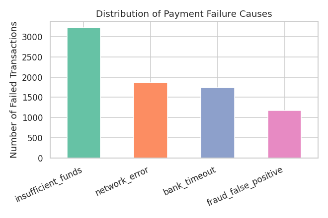

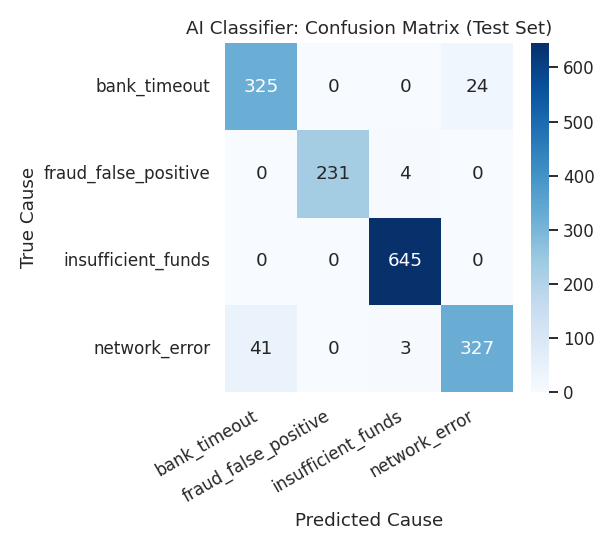

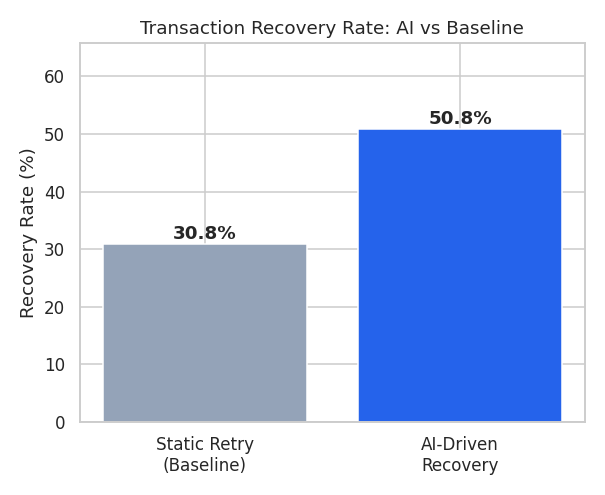

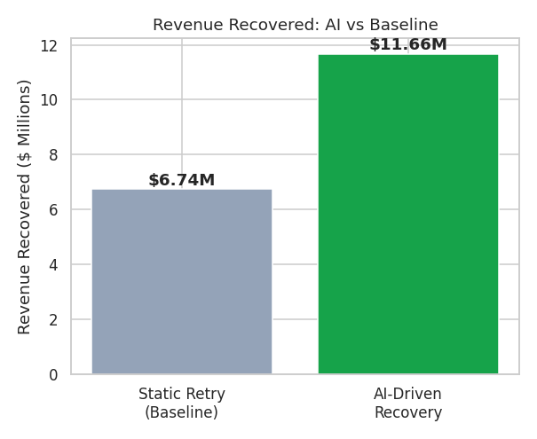

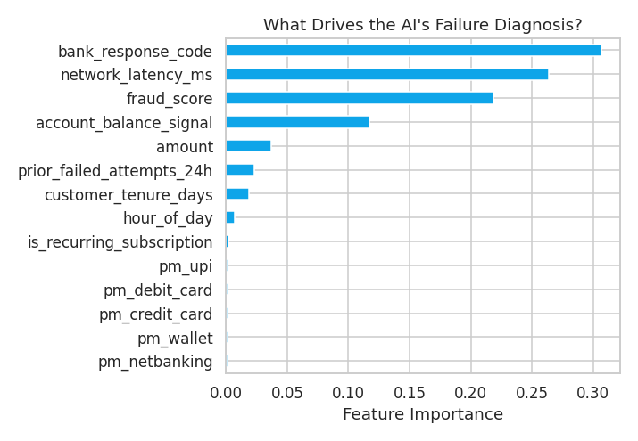

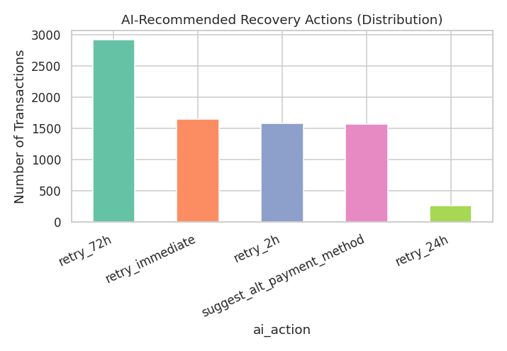

```python
from IPython.display import Image, display
for f in ["chart_1_failure_distribution.png", "chart_2_confusion_matrix.png",
          "chart_3_recovery_rate.png", "chart_4_revenue_recovered.png",
          "chart_5_feature_importance.png", "chart_6_action_mix.png"]:
    display(Image(filename=f))
```

## Step 6 — Live Demo: Score a New Failed Transaction

Try it yourself — change the values below to see the AI diagnose the failure and recommend an action in real time.

```python
import joblib, pandas as pd, importlib.util

clf = joblib.load("failure_classifier.pkl")
le = joblib.load("label_encoder.pkl")
feature_cols = joblib.load("feature_cols.pkl")

spec = importlib.util.spec_from_file_location("rec_engine", "03_recommendation_engine.py")
rec_engine = importlib.util.module_from_spec(spec)
spec.loader.exec_module(rec_engine)

def diagnose_and_recommend(transaction: dict) -> dict:
    """
    transaction: dict of raw signals for one failed payment, e.g.
    {
        "amount": 4200.0,
        "payment_method": "credit_card",
        "bank_response_code": 59,
        "network_latency_ms": 210,
        "fraud_score": 0.82,
        "prior_failed_attempts_24h": 0,
        "customer_tenure_days": 800,
        "account_balance_signal": 0.7,
        "hour_of_day": 14,
        "is_recurring_subscription": 0,
    }
    """
    row = pd.DataFrame([transaction])
    row_encoded = pd.get_dummies(row, columns=["payment_method"], prefix="pm")
    for c in feature_cols:
        if c not in row_encoded.columns:
            row_encoded[c] = 0
    X = row_encoded[feature_cols]

    pred = clf.predict(X)[0]
    cause = le.inverse_transform([pred])[0]
    proba = dict(zip(le.classes_, clf.predict_proba(X)[0].round(3)))

    rec = rec_engine.recommend_action(cause, transaction)

    return {
        "predicted_failure_cause": cause,
        "cause_probabilities": proba,
        "recommended_action": rec["recommended_action"],
        "expected_success_probability": rec["expected_success_prob"],
        "all_action_scores": rec["all_action_scores"],
    }

# --- Example: a large purchase from a long-time customer, high fraud score ---
sample_transaction = {
    "amount": 4200.0,
    "payment_method": "credit_card",
    "bank_response_code": 59,
    "network_latency_ms": 210,
    "fraud_score": 0.82,
    "prior_failed_attempts_24h": 0,
    "customer_tenure_days": 800,
    "account_balance_signal": 0.7,
    "hour_of_day": 14,
    "is_recurring_subscription": 0,
}

result = diagnose_and_recommend(sample_transaction)
import json
print(json.dumps(result, indent=2))
```

```
{
  "predicted_failure_cause": "fraud_false_positive",
  "cause_probabilities": {
    "bank_timeout": 0.0,
    "fraud_false_positive": 0.998,
    "insufficient_funds": 0.001,
    "network_error": 0.0
  },
  "recommended_action": "suggest_alt_payment_method",
  "expected_success_probability": 0.605,
  "all_action_scores": {
    "retry_immediate": 0.08,
    "retry_2h": 0.1,
    "retry_24h": 0.15,
    "retry_72h": 0.2,
    "suggest_alt_payment_method": 0.605,
    "customer_nudge": 0.517
  }
}
```

## Business Impact Summary

```python
summary = pd.read_csv("business_impact_summary.csv", index_col=0).iloc[:, 0]
summary
```

```
total_failed_transactions                  8.000000e+03
total_failed_value                         2.423249e+07
ai_recovery_rate                           5.079000e-01
baseline_recovery_rate                     3.081000e-01
recovery_rate_lift_pct_points              1.997000e+01
ai_recovered_value                         1.166424e+07
baseline_recovered_value                   6.744187e+06
incremental_revenue_recovered              4.920049e+06
incremental_revenue_pct_of_total_failed    2.030000e+01
Name: 0, dtype: float64
```